# Part I - Communicate Data Findings: Ford GoBike System Data

## Introduction

> This dataset includes information about individual rides made in a bike-sharing system covering the greater San Francisco Bay area. The dataset contains 183412 rows and 18 columns.

## Preliminary Wrangling

```python
# import all packages and set plots to be embedded inline
import numpy as np
import pandas as pd
import matplotlib.pyplot as plt
import seaborn as sb

%matplotlib inline
```

Now, we load our dataset into the workspace. Note: A little data wrangling was done on the dataset before uplaoding, so as the make it suitable for the desired purpose.

```python
# load in the dataset into a pandas dataframe, print statistics
df = diamonds = pd.read_csv('201902-fordgobike-tripdata1.csv')
df
```

[output not shown]

183412 rows × 18 columns

## Data Accessing

Now, we will assess our dataset to observe the shape and structure of the dataset

```python
# high-level overview of data shape and composition
print(df.shape)
print(df.dtypes)
print(df.head(10))
```

```
(183412, 18)
duration_sec                 int64
start_date                  object
start_time                  object
end_date                    object
end_time                    object
start_station_id           float64
start_station_name          object
start_station_latitude     float64
start_station_longitude    float64
end_station_id             float64
end_station_name            object
end_station_latitude       float64
end_station_longitude      float64
bike_id                      int64
user_type                   object
member_birth_year          float64
member_gender               object
bike_share_for_all_trip     object
dtype: object
   duration_sec  start_date start_time    end_date  end_time  \
0         52185  2019-02-28   17:32:10  2019-03-01  08:01:56
1         42521  2019-02-28   18:53:22  2019-03-01  06:42:03
2         61854  2019-02-28   12:13:13  2019-03-01  05:24:08
3         36490  2019-02-28   17:54:26  2019-03-01  04:02:37
4          1585  2019-02-28   23:54:19  2019-03-01  00:20:44
5          1793  2019-02-28   23:49:59  2019-03-01  00:19:52
6          1147  2019-02-28   23:55:35  2019-03-01  00:14:43
7          1615  2019-02-28   23:41:07  2019-03-01  00:08:03
8          1570  2019-02-28   23:41:49  2019-03-01  00:08:00
9          1049  2019-02-28   23:49:48  2019-03-01  00:07:17

   start_station_id                                start_station_name  \
0              21.0  Montgomery St BART Station (Market St at 2nd St)
1              23.0                     The Embarcadero at Steuart St
2              86.0                           Market St at Dolores St
3             375.0                           Grove St at Masonic Ave
4               7.0                               Frank H Ogawa Plaza
5              93.0                      4th St at Mission Bay Blvd S
6             300.0                              Palm St at Willow St
```

[output cut: 36 more lines]

```
7            -122.421025     6329  Subscriber             1989.0
8            -122.421025     6548  Subscriber             1988.0
9            -122.421339     6488  Subscriber             1992.0

  member_gender bike_share_for_all_trip
0          Male                      No
1           NaN                      No
2          Male                      No
3         Other                      No
4          Male                     Yes
5          Male                      No
6        Female                      No
7          Male                      No
8         Other                      No
9          Male                      No
```

## Data cleaning

Now we clean the dataset to make it fit for analysis

1. Dealing with nulls

Let's examine the dataset for nulls:

```python
df.isnull().sum()
```

```
duration_sec                  0
start_date                    0
start_time                    0
end_date                      0
end_time                      0
start_station_id            197
start_station_name          197
start_station_latitude        0
start_station_longitude       0
end_station_id              197
end_station_name            197
end_station_latitude          0
end_station_longitude         0
bike_id                       0
user_type                     0
member_birth_year          8265
member_gender              8265
bike_share_for_all_trip       0
dtype: int64
```

Apparently, the start_station_id, start_station_name, end_station_id and end_station_name columns have 197 nulls while the member_birth_year and member_gender have 8265 nulls. Because the number of nulls in the former(197) is negligible compared to the whole dataset, we will drop the null. The latter however, has 8265 nulls, which is too much to be termed negligible at this point: we won't drop the nulls

```python
# dropping the nulls in the former
df = df[df['start_station_id'].notna()]
```

```python
df.isnull().sum()
```

```
duration_sec                  0
start_date                    0
start_time                    0
end_date                      0
end_time                      0
start_station_id              0
start_station_name            0
start_station_latitude        0
start_station_longitude       0
end_station_id                0
end_station_name              0
end_station_latitude          0
end_station_longitude         0
bike_id                       0
user_type                     0
member_birth_year          8263
member_gender              8263
bike_share_for_all_trip       0
dtype: int64
```

Now, those nulls have been dropped!!!

1. Changing data types

We will convert the start_date, start_time, end_date and end_time columns to datetime datatype. We will also convert the start_station_id and end_station_id to int datatype

```python
df['start_date']=pd.to_datetime(df['start_date'])
df['start_time']=pd.to_datetime(df['start_time'])
df['end_date']=pd.to_datetime(df['end_date'])
df['end_time']=pd.to_datetime(df['end_time'])
df['start_station_id'] = df['start_station_id'].astype(int)
df['end_station_id'] = df['end_station_id'].astype(int)
```

[output not shown]

```python
df.dtypes
```

```
duration_sec                        int64
start_date                 datetime64[ns]
start_time                 datetime64[ns]
end_date                   datetime64[ns]
end_time                   datetime64[ns]
start_station_id                    int64
start_station_name                 object
start_station_latitude            float64
start_station_longitude           float64
end_station_id                      int64
end_station_name                   object
end_station_latitude              float64
end_station_longitude             float64
bike_id                             int64
user_type                          object
member_birth_year                 float64
member_gender                      object
bike_share_for_all_trip            object
dtype: object
```

Task completed. Great!!!

```python
df.head(1)
```

|  | duration_sec | start_date | start_time | end_date | end_time | start_station_id | start_station_name | start_station_latitude | start_station_longitude | end_station_id | end_station_name | end_station_latitude | end_station_longitude | bike_id | user_type | member_birth_year | member_gender | bike_share_for_all_trip |
| --- | --- | --- | --- | --- | --- | --- | --- | --- | --- | --- | --- | --- | --- | --- | --- | --- | --- | --- |
| 0 | 52185 | 2019-02-28 | 2022-05-27 17:32:10 | 2019-03-01 | 2022-05-27 08:01:56 | 21 | Montgomery St BART Station (Market St at 2nd St) | 37.789625 | -122.400811 | 13 | Commercial St at Montgomery St | 37.794231 | -122.402923 | 4902 | Customer | 1984.0 | Male | No |

1. Calculate distance from longitude and latitude columns

From the start_station_latitude, start_station_longitude, end_station_latitude and end_station_longitude column, we will attempt to compute the relative ride distance for each entry. The computation process will be categorised into the folloing steps:

1. Converting the 4 columns from degrees to radain
2. Calculating the difference in longitudes and latitudes
3. Computing the distance

Step 1: Converting the 4 columns from degrees to radain

```python
import math
def deg_to_rad(dr):
    return (dr*math.pi)/180
df['start_station_latitude'] = deg_to_rad(df['start_station_latitude'])
df['end_station_latitude'] = deg_to_rad(df['end_station_latitude'])
df['start_station_longitude'] = deg_to_rad(df['start_station_longitude'])
df['end_station_longitude'] = deg_to_rad(df['end_station_longitude'])
```

```python
df.head(1)
```

|  | duration_sec | start_date | start_time | end_date | end_time | start_station_id | start_station_name | start_station_latitude | start_station_longitude | end_station_id | end_station_name | end_station_latitude | end_station_longitude | bike_id | user_type | member_birth_year | member_gender | bike_share_for_all_trip |
| --- | --- | --- | --- | --- | --- | --- | --- | --- | --- | --- | --- | --- | --- | --- | --- | --- | --- | --- |
| 0 | 52185 | 2019-02-28 | 2022-05-27 17:32:10 | 2019-03-01 | 2022-05-27 08:01:56 | 21 | Montgomery St BART Station (Market St at 2nd St) | 0.659553 | -2.136297 | 13 | Commercial St at Montgomery St | 0.659634 | -2.136334 | 4902 | Customer | 1984.0 | Male | No |

The 4 columns are now in radian

Step 2: Calculating the difference in longitudes and latitudes

```python
df['diff_lon'] =df['end_station_longitude'] - df['start_station_longitude']
df['diff_lat'] = df['end_station_latitude'] - df['start_station_latitude']
```

```python
df.head(1)
```

|  | duration_sec | start_date | start_time | end_date | end_time | start_station_id | start_station_name | start_station_latitude | start_station_longitude | end_station_id | end_station_name | end_station_latitude | end_station_longitude | bike_id | user_type | member_birth_year | member_gender | bike_share_for_all_trip | diff_lon | diff_lat |
| --- | --- | --- | --- | --- | --- | --- | --- | --- | --- | --- | --- | --- | --- | --- | --- | --- | --- | --- | --- | --- |
| 0 | 52185 | 2019-02-28 | 2022-05-27 17:32:10 | 2019-03-01 | 2022-05-27 08:01:56 | 21 | Montgomery St BART Station (Market St at 2nd St) | 0.659553 | -2.136297 | 13 | Commercial St at Montgomery St | 0.659634 | -2.136334 | 4902 | Customer | 1984.0 | Male | No | -0.000037 | 0.00008 |

Great!!!

Step 3: Computing the relative distance

To compute the distance, we use the Haversine formula as given below: diff_lon = lon2 - lon1

```
diff_lat = lat2 - lat1

a = sin(diff_lat / 2)**2 + cos(lat1) * cos(lat2) * sin(diff_lon / 2)**2

c = 2 * asin(sqrt(a))

distance = r* c

where r= Radius of earth in kilometers = 6371
```

```python
# Computing the ralative ride distance using Haversine formula above
df['a'] = np.sin(df['diff_lat'] / 2)**2 + np.cos(df['start_station_latitude']) * np.cos(df['end_station_latitude']) * np.sin(df['diff_lon'] / 2)**2
df['b']= np.sqrt((df['a']))
df['c'] = 2 * (np.arcsin((df['b'])))
r = 6371
df['distance'] = r * df['c']
df.head(1)
```

|  | duration_sec | start_date | start_time | end_date | end_time | start_station_id | start_station_name | start_station_latitude | start_station_longitude | end_station_id | ... | user_type | member_birth_year | member_gender | bike_share_for_all_trip | diff_lon | diff_lat | a | b | c | distance |
| --- | --- | --- | --- | --- | --- | --- | --- | --- | --- | --- | --- | --- | --- | --- | --- | --- | --- | --- | --- | --- | --- |
| 0 | 52185 | 2019-02-28 | 2022-05-27 17:32:10 | 2019-03-01 | 2022-05-27 08:01:56 | 21 | Montgomery St BART Station (Market St at 2nd St) | 0.659553 | -2.136297 | 13 | ... | Customer | 1984.0 | Male | No | -0.000037 | 0.00008 | 1.827482e-09 | 0.000043 | 0.000085 | 0.544709 |

1 rows × 24 columns

Fantastic. Now we have our ride distance column

1. Drop unwanted columns

Now we will drop columns that are not crucial to our analysis

```python
df.drop(['start_station_longitude', 'end_station_longitude', 'start_station_latitude', 'end_station_latitude', 'diff_lon', 'diff_lat', 'a', 'b', 'c'], axis = 1, inplace=True)
df.head()
```

|  | duration_sec | start_date | start_time | end_date | end_time | start_station_id | start_station_name | end_station_id | end_station_name | bike_id | user_type | member_birth_year | member_gender | bike_share_for_all_trip | distance |
| --- | --- | --- | --- | --- | --- | --- | --- | --- | --- | --- | --- | --- | --- | --- | --- |
| 0 | 52185 | 2019-02-28 | 2022-05-27 17:32:10 | 2019-03-01 | 2022-05-27 08:01:56 | 21 | Montgomery St BART Station (Market St at 2nd St) | 13 | Commercial St at Montgomery St | 4902 | Customer | 1984.0 | Male | No | 0.544709 |
| 1 | 42521 | 2019-02-28 | 2022-05-27 18:53:22 | 2019-03-01 | 2022-05-27 06:42:03 | 23 | The Embarcadero at Steuart St | 81 | Berry St at 4th St | 2535 | Customer | NaN | NaN | No | 1.742999 |
| 2 | 61854 | 2019-02-28 | 2022-05-27 12:13:13 | 2019-03-01 | 2022-05-27 05:24:08 | 86 | Market St at Dolores St | 3 | Powell St BART Station (Market St at 4th St) | 5905 | Customer | 1972.0 | Male | No | 2.704543 |
| 3 | 36490 | 2019-02-28 | 2022-05-27 17:54:26 | 2019-03-01 | 2022-05-27 04:02:37 | 375 | Grove St at Masonic Ave | 70 | Central Ave at Fell St | 6638 | Subscriber | 1989.0 | Other | No | 0.260741 |
| 4 | 1585 | 2019-02-28 | 2022-05-27 23:54:19 | 2019-03-01 | 2022-05-27 00:20:44 | 7 | Frank H Ogawa Plaza | 222 | 10th Ave at E 15th St | 4898 | Subscriber | 1974.0 | Male | Yes | 2.409305 |

```python
df.shape
```

```
(183215, 15)
```

Now, we have our desired dataset!!!

### What is the structure of your dataset?

> The dataset has 183215 rows and 15 columns

### What is/are the main feature(s) of interest in your dataset?

> For this anlysis, the main feature of interst in the dataset is the duration of rides (duration_sec)

### What features in the dataset do you think will help support your investigation into your feature(s) of interest?

> I expect that the feature that should have the strongest influence on duration of rides is the distance. I aslo expect that other factors such as start and end stations as well as user_type will also influence the duration of rides.

## Univariate Exploration

For this univariate exploration, we are going to investigate the distribution of some individual variables.

To start with, let us create a copy of our dataset and save it as df1

```python
df1 = df.copy()
```

Dataset copied!

## 1. The duration_sec variable

Being our main feature, we are going to investigate the ride duration variable(duration_sec). We will plot the distribution on an histogram

QUESTION:What is the average ride duration for bikeshare trips

```python
df1.describe()
```

|  | duration_sec | start_station_id | end_station_id | bike_id | member_birth_year | distance |
| --- | --- | --- | --- | --- | --- | --- |
| count | 183215.000000 | 183215.000000 | 183215.000000 | 183215.000000 | 174952.000000 | 183215.000000 |
| mean | 725.902017 | 138.590427 | 136.249123 | 4473.218792 | 1984.803135 | 1.691352 |
| std | 1795.078654 | 111.778864 | 111.515131 | 1665.249372 | 10.118731 | 1.097611 |
| min | 61.000000 | 3.000000 | 3.000000 | 11.000000 | 1878.000000 | 0.000000 |
| 25% | 325.000000 | 47.000000 | 44.000000 | 3777.000000 | 1980.000000 | 0.910955 |
| 50% | 514.000000 | 104.000000 | 100.000000 | 4958.000000 | 1987.000000 | 1.432473 |
| 75% | 796.000000 | 239.000000 | 235.000000 | 5503.000000 | 1992.000000 | 2.226127 |
| max | 85444.000000 | 398.000000 | 398.000000 | 6645.000000 | 2001.000000 | 69.469241 |

VISUALIZATION:

[figure not shown]

```python
# start with a standard-scaled plot
binsize = 200
bins = np.arange(61, df1['duration_sec'].max()+binsize, binsize)

plt.figure(figsize=[8, 5])
plt.hist(data = df1, x = 'duration_sec', bins = bins)
plt.title('Investigating the duration variable')
plt.xlabel('Price ($)')
plt.show()
```

Yes. The structure or shape of the histogram affirms the presence of outliers.

To zoom in into the desired part of the plot, we can make use of axis limit.

[figure not shown]

```python
# Setting the axis limit between 61 and 4000:
binsize = 100
bins = np.arange(61, df1['duration_sec'].max()+binsize, binsize)

plt.figure(figsize=[8, 5])
plt.hist(data = df1, x = 'duration_sec', bins = bins)
plt.title('Investigating the duration variable')
plt.xlim((61,4000))
plt.xlabel('Price ($)')
plt.show()
```

Now, we have a more relatable plot

Alternatively, we can remove outliers from our dataset before ploting the distribution on an histogram

```python
# Removing values <= 4000 as outliers
df2=df1[df1.duration_sec <4000]
```

```python
df2.describe()
```

|  | duration_sec | start_station_id | end_station_id | bike_id | member_birth_year | distance |
| --- | --- | --- | --- | --- | --- | --- |
| count | 181725.000000 | 181725.000000 | 181725.000000 | 181725.000000 | 173754.000000 | 181725.000000 |
| mean | 627.269913 | 138.548923 | 136.089052 | 4475.435130 | 1984.807947 | 1.692463 |
| std | 461.948468 | 111.573122 | 111.243525 | 1663.727124 | 10.117217 | 1.082002 |
| min | 61.000000 | 3.000000 | 3.000000 | 11.000000 | 1878.000000 | 0.000000 |
| 25% | 324.000000 | 47.000000 | 44.000000 | 3783.000000 | 1980.000000 | 0.916541 |
| 50% | 511.000000 | 104.000000 | 100.000000 | 4959.000000 | 1987.000000 | 1.432473 |
| 75% | 786.000000 | 239.000000 | 233.000000 | 5503.000000 | 1992.000000 | 2.226186 |
| max | 3999.000000 | 398.000000 | 398.000000 | 6645.000000 | 2001.000000 | 15.673955 |

Now we plot df2 on an histogram

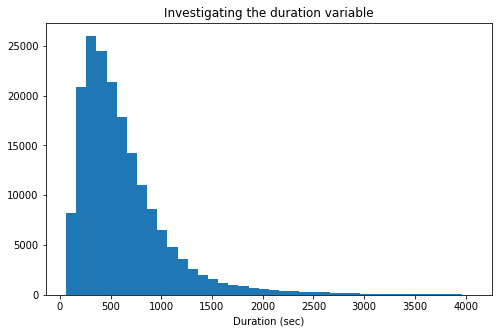

```python
# start with a standard-scaled plot
binsize = 100
bins = np.arange(61, df2['duration_sec'].max()+binsize, binsize)

plt.figure(figsize=[8, 5])
plt.hist(data = df2, x = 'duration_sec', bins = bins)
plt.xlabel('Duration (sec)')
plt.title('Investigating the duration variable')
plt.show()
```

OBSERVATION:

Great. The plot obtained is similar to the one we got using axis limits

The histogram plot of duration is Right_skewed. Most of the trips have thier ride duration less than 1000 seconds

## 2. Predictor Variable: distance

QUESTION: What's the average ride distance for bikeshare trips?

Now, let us examine the distance variable

```python
df1.distance.describe()
```

```
count    183215.000000
mean          1.691352
std           1.097611
min           0.000000
25%           0.910955
50%           1.432473
75%           2.226127
max          69.469241
Name: distance, dtype: float64
```

Now, let us plot the distance vairable on an histogram

VISUALIZATION:

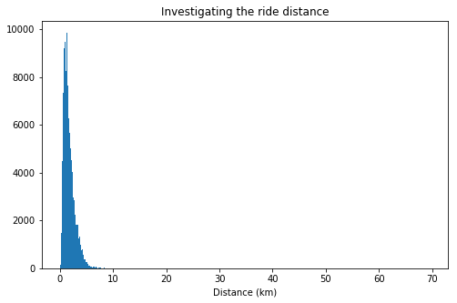

```python
binsize = 0.1
bins = np.arange(0, df1['distance'].max()+binsize, binsize)

plt.figure(figsize=[8, 5])
plt.hist(data = df1, x = 'distance', bins = bins)
plt.title('Investigating the ride distance')
plt.xlabel('Distance (km)')
plt.show()
```

The plot indicates the presence of outliers Now, let us make use of axis limit between 0 and 3

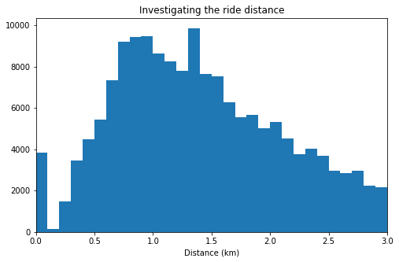

```python
binsize = 0.1
bins = np.arange(0, df1['distance'].max()+binsize, binsize)

plt.figure(figsize=[8, 5])
plt.hist(data = df1, x = 'distance', bins = bins)
plt.title('Investigating the ride distance')
plt.xlim((0,3))
plt.xlabel('Distance (km)')
plt.show()
```

OBSERVATION:

```python
# Investigating cases where distance is zero
df1[df1.distance==0].head()
```

|  | duration_sec | start_date | start_time | end_date | end_time | start_station_id | start_station_name | end_station_id | end_station_name | bike_id | user_type | member_birth_year | member_gender | bike_share_for_all_trip | distance |
| --- | --- | --- | --- | --- | --- | --- | --- | --- | --- | --- | --- | --- | --- | --- | --- |
| 19 | 874 | 2019-02-28 | 2022-05-27 23:43:05 | 2019-02-28 | 2022-05-27 23:57:40 | 180 | Telegraph Ave at 23rd St | 180 | Telegraph Ave at 23rd St | 5629 | Customer | 1978.0 | Male | No | 0.0 |
| 27 | 408 | 2019-02-28 | 2022-05-27 23:48:08 | 2019-02-28 | 2022-05-27 23:54:57 | 78 | Folsom St at 9th St | 78 | Folsom St at 9th St | 5410 | Subscriber | 1982.0 | Male | No | 0.0 |
| 34 | 471 | 2019-02-28 | 2022-05-27 23:42:43 | 2019-02-28 | 2022-05-27 23:50:34 | 133 | Valencia St at 22nd St | 133 | Valencia St at 22nd St | 5559 | Subscriber | 1992.0 | Male | No | 0.0 |
| 53 | 3418 | 2019-02-28 | 2022-05-27 22:41:16 | 2019-02-28 | 2022-05-27 23:38:14 | 11 | Davis St at Jackson St | 11 | Davis St at Jackson St | 319 | Customer | NaN | NaN | No | 0.0 |
| 55 | 3478 | 2019-02-28 | 2022-05-27 22:39:35 | 2019-02-28 | 2022-05-27 23:37:33 | 11 | Davis St at Jackson St | 11 | Davis St at Jackson St | 1846 | Subscriber | 1995.0 | Male | No | 0.0 |

As observed above, the start_station and end_station for these cases are the same. So the total relative distance is truely zero

## 3.Predictor Variable: user_type

QUESTION: Which of the user type is associated with more trips with bikeshare?

Let us start by examining the user_type column

```python
df1.user_type.describe()
```

```
count         183215
unique             2
top       Subscriber
freq          163414
Name: user_type, dtype: object
```

```python
df1.groupby(['user_type']).count()
```

| user_type | duration_sec | start_date | start_time | end_date | end_time | start_station_id | start_station_name | end_station_id | end_station_name | bike_id | member_birth_year | member_gender | bike_share_for_all_trip | distance |
| --- | --- | --- | --- | --- | --- | --- | --- | --- | --- | --- | --- | --- | --- | --- |
| Customer | 19801 | 19801 | 19801 | 19801 | 19801 | 19801 | 19801 | 19801 | 19801 | 19801 | 16566 | 16566 | 19801 | 19801 |
| Subscriber | 163414 | 163414 | 163414 | 163414 | 163414 | 163414 | 163414 | 163414 | 163414 | 163414 | 158386 | 158386 | 163414 | 163414 |

These infer that we have two user types: Customer and Subscriber

VISUALIZATION:

Let us plot the user_type variable on a bar chart

```
Text(0,0.5,'Frequency')
```

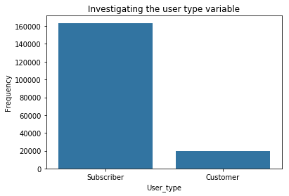

```python
base_color= sb.color_palette()[0]
user_order = df1['user_type'].value_counts().index
sb.countplot(data=df1, x='user_type', color=base_color, order = user_order);
plt.title('Investigating the user type variable')
plt.xlabel('User_type')
plt.ylabel('Frequency')
```

Now, lets see how it looks on a pie chart

```
(-1.1064831933316563,
 1.1059661526599407,
 -1.1012582542367904,
 1.1111910917548067)
```

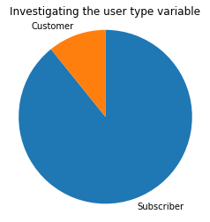

```python
sorted_counts = df1['user_type'].value_counts()

plt.pie(sorted_counts, labels = sorted_counts.index, startangle = 90, counterclock = False);
plt.title('Investigating the user type variable')
plt.axis('square')
```

ONSERVATION:

From both plots, it is evident that the subscribers outnumbers customers in this dataset

## 4. Predictor variable: member_birth_year

QUESTION: Which age group is associated with more trips with bikeshare?

Let's looks at the member_birth_year column

```python
df1.member_birth_year.describe()
```

```
count    174952.000000
mean       1984.803135
std          10.118731
min        1878.000000
25%        1980.000000
50%        1987.000000
75%        1992.000000
max        2001.000000
Name: member_birth_year, dtype: float64
```

To be able to effectively plot this variable on an histogram, we need to drop all the nulls in that column

```python
df3=df1[df1['member_birth_year'].notna()]
```

```python
df3.member_birth_year.describe()
```

```
count    174952.000000
mean       1984.803135
std          10.118731
min        1878.000000
25%        1980.000000
50%        1987.000000
75%        1992.000000
max        2001.000000
Name: member_birth_year, dtype: float64
```

VISUALIZATION:

We will set the axis limit of the x axis between 1930 and 2005

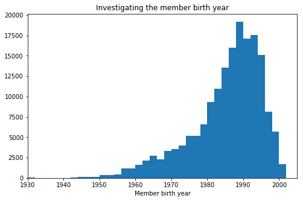

```python
binsize = 2
bins = np.arange(1878, df3['member_birth_year'].max()+binsize, binsize)

plt.figure(figsize=[8, 5])
plt.hist(data = df3, x = 'member_birth_year', bins = bins)
plt.title('Investigating the member birth year')
plt.xlabel('Member birth year')
plt.xlim((1930,2005))
plt.show()
```

OBSERVATION:

Cool!!! The distribution is slightly left_skewed. Most of the birth years are are below 1990. Individuals born between 1960 and 2000 use bikeshare more.

## 5. Predictor variable: member_gender

QUESTION: Which gender uses bikeshare the most?

Let's take a look at the member_gender column

```python
df1.member_gender.describe()
```

```
count     174952
unique         3
top         Male
freq      130500
Name: member_gender, dtype: object
```

```python
df1.groupby(['member_gender']).count()
```

| member_gender | duration_sec | start_date | start_time | end_date | end_time | start_station_id | start_station_name | end_station_id | end_station_name | bike_id | user_type | member_birth_year | bike_share_for_all_trip | distance |
| --- | --- | --- | --- | --- | --- | --- | --- | --- | --- | --- | --- | --- | --- | --- |
| Female | 40805 | 40805 | 40805 | 40805 | 40805 | 40805 | 40805 | 40805 | 40805 | 40805 | 40805 | 40805 | 40805 | 40805 |
| Male | 130500 | 130500 | 130500 | 130500 | 130500 | 130500 | 130500 | 130500 | 130500 | 130500 | 130500 | 130500 | 130500 | 130500 |
| Other | 3647 | 3647 | 3647 | 3647 | 3647 | 3647 | 3647 | 3647 | 3647 | 3647 | 3647 | 3647 | 3647 | 3647 |

VISUALIZATION:

Let us plot this variable on a bar chart

```
Text(0,0.5,'Frequency')
```

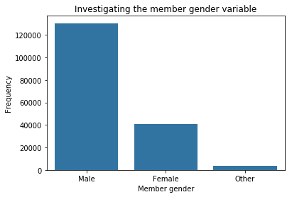

```python
base_color= sb.color_palette()[0]
user_order = df1['member_gender'].value_counts().index
sb.countplot(data=df1, x='member_gender', color=base_color, order = user_order);
plt.title('Investigating the member gender variable')
plt.xlabel('Member gender')
plt.ylabel('Frequency')
```

Let's examine this same variable on a doughnut plot

```
(-1.1072592340323726,
 1.1203835586186992,
 -1.1199361631365747,
 1.1077066295144971)
```

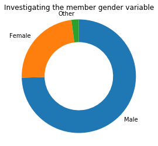

```python
sorted_counts = df1['member_gender'].value_counts()

plt.pie(sorted_counts, labels = sorted_counts.index, startangle = 90,
        counterclock = False, wedgeprops = {'width' : 0.4});
plt.title('Investigating the member gender variable')
plt.axis('square')
```

OBSERVATION:

Evidently, we have more member who are males(130500) compared to females(40805). We also have another class of gender names others(3647)

## Predictor variable: bike_share_for_all_trip

QUESTION: Do people use bikeshare for all trip often?

Let's examine the bike_share_for_all_trip variable

```python
df1.bike_share_for_all_trip.describe()
```

```
count     183215
unique         2
top           No
freq      165869
Name: bike_share_for_all_trip, dtype: object
```

```python
df1.groupby(['bike_share_for_all_trip']).count()
```

| bike_share_for_all_trip | duration_sec | start_date | start_time | end_date | end_time | start_station_id | start_station_name | end_station_id | end_station_name | bike_id | user_type | member_birth_year | member_gender | distance |
| --- | --- | --- | --- | --- | --- | --- | --- | --- | --- | --- | --- | --- | --- | --- |
| No | 165869 | 165869 | 165869 | 165869 | 165869 | 165869 | 165869 | 165869 | 165869 | 165869 | 165869 | 157606 | 157606 | 165869 |
| Yes | 17346 | 17346 | 17346 | 17346 | 17346 | 17346 | 17346 | 17346 | 17346 | 17346 | 17346 | 17346 | 17346 | 17346 |

VISUALIZATION:

Now, let us visualize the bike_share_for_all_trip on a pie chart

```
(-1.1073104362512594,
 1.1072280301921935,
 -1.1054719257666368,
 1.1090665406768161)
```

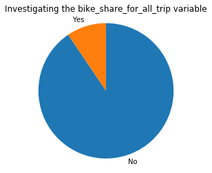

```python
sorted_counts = df1['bike_share_for_all_trip'].value_counts()

plt.pie(sorted_counts, labels = sorted_counts.index, startangle = 90, counterclock = False);
plt.title('Investigating the bike_share_for_all_trip variable')
plt.axis('square')
```

OBSERVATION:

Apparently, most of riders did not utilize bikeshare for the whole trip. 17346 of the riders used bikeshare for the whole trip while 165869 of them used other means alongside bikeshare

### Discuss the distribution(s) of your variable(s) of interest. Were there any unusual points? Did you need to perform any transformations?

> The duration variable took on a large range of values, so I look at the data using an axis limit between 61 and 4000 in other to get the desired outcome. Also, I removed outliers from the dataset before ploting the distribution on an histogram, the result obtained was similar to that obtained using axis limit. The plot obtained is Right_skewed. Most of the trips have thier ride duration less than 1000 seconds

### Of the features you investigated, were there any unusual distributions? Did you perform any operations on the data to tidy, adjust, or change the form of the data? If so, why did you do this?

> When investigating the distance variables, a number of outlier points were identified. Hence, to obtained the required visualization, I made use of axis limit between 0 and 3. This gave a more relatable plot

## 1. Distance vs Duration_sec

QUESTION: What's the relationship between distance and ride duration

To start off with, we want to look at the correlations present between distance and duration_sec

Since both of them are quantitative variables, we will visualize their relationship on a scattered plot.

As a result of the presence of outliers and also to avoid overplotting, an axis limit beteen 0 and 10km was set for the x axis.

Jitters and transparancy settings were also employed to yield the best output

VISUALIZATION:

```
Text(0,0.5,'Duration_sec(seconds)')
```

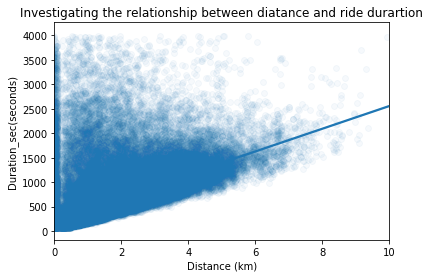

```python
sb.regplot(data =df2, x='distance', y = 'duration_sec', x_jitter = 0.1, scatter_kws= {'alpha':1/25});
plt.xlabel('Distance (km)')
plt.title('Investigating the relationship between diatance and ride durartion')
plt.xlim((0,10))
plt.ylabel('Duration_sec(seconds)')
```

OBSERVATION:

As expected, there is a positive correlation between distance and duration. The farther the distance, the more the ride duration. Most distance for most rides are below 4km and most rides takes below 2000 seconds

## 2. User_type vs Duration_sec

QUESTION: What's the relationship between user type and ride duration

To visualize the relatioship between these quantitative and qualitative variables, we will make use of a violin plot.

VISUALIZATION:

```
Text(0.5,1,'Investigating the relationship between user type and ride durartion')
```

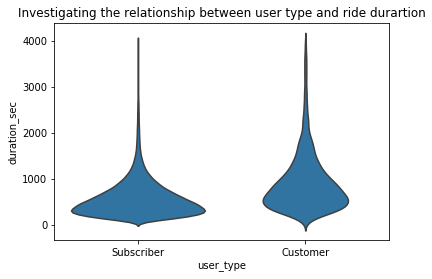

```python
base_color = sb.color_palette()[0]
sb.violinplot(data=df2, x='user_type', y='duration_sec', color=base_color, inner=None)
plt.title('Investigating the relationship between user type and ride durartion')
```

## 3. Member_birth_year vs Duration

QUESTION: What's the relationship between member birth year and ride duration?

Let's take a look the member_birth_year column

```python
df1.member_birth_year.describe()
```

```
count    174952.000000
mean       1984.803135
std          10.118731
min        1878.000000
25%        1980.000000
50%        1987.000000
75%        1992.000000
max        2001.000000
Name: member_birth_year, dtype: float64
```

VISUALIZATION:

Now, we will plot this variable on a scattered plot with jitter and transperency settings

```
Text(0,0.5,'Duration_sec(seconds)')
```

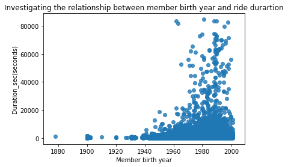

```python
sb.regplot(data =df1, x='member_birth_year', y = 'duration_sec', x_jitter = 0.1, fit_reg=False);
plt.xlabel('Member birth year')
plt.title('Investigating the relationship between member birth year and ride durartion')
plt.ylabel('Duration_sec(seconds)')
```

## 4. Member_gender vs Duration

QUESTION: What's the relationship between member gender and ride duration

Let's examine the member_gender column

```python
df1.member_gender.describe()
```

```
count     174952
unique         3
top         Male
freq      130500
Name: member_gender, dtype: object
```

VISUALIZATION:

Now, we will visualize the relationship between member's gender and ride duration using a violin plot and a box plot together by the means of subplots

```
Text(0.5,1,'Investigating the relationship between members gender and ride durartion')
```

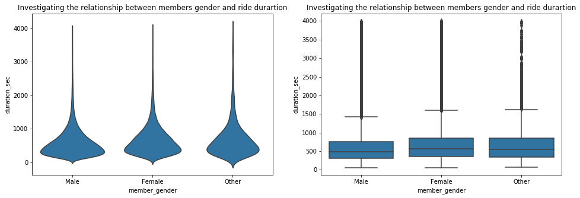

```python
plt.figure(figsize = [16, 5])
base_color = sb.color_palette()[0]

plt.subplot(1, 2, 1)
sb.violinplot(data=df2, x='member_gender', y='duration_sec', color=base_color, inner=None)
plt.title('Investigating the relationship between members gender and ride durartion')

plt.subplot(1, 2, 2)
sb.boxplot(data=df2, x='member_gender', y='duration_sec', color=base_color)
plt.title('Investigating the relationship between members gender and ride durartion')
```

OBSERVATION:

The long tail shape observed for all variable depicts the presence of outliers. The shape for the male variable has the longest width, depicting the highest number of entries followed by female ad then others. The box plot also depicts similar observation.

## 5. bike_share_for_all_trip vs duration

QUESTION: What's the relationship between bike_share_for_all_trip and ride duration

```python
df1.bike_share_for_all_trip.describe()
```

```
count     183215
unique         2
top           No
freq      165869
Name: bike_share_for_all_trip, dtype: object
```

VISUALIZATION:

```
Text(0.5,1,'Investigating the relationship between bike_share_for_all variable and ride durartion')
```

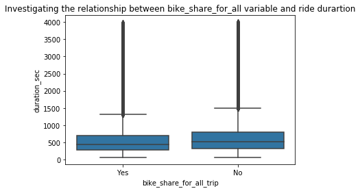

```python
sb.boxplot(data=df2, x='bike_share_for_all_trip', y='duration_sec', color=base_color)
plt.title('Investigating the relationship between bike_share_for_all variable and ride durartion')
```

OBSERVATION:

From the plot it is evident that those who do not use bike share for all the trip spend more time on the trip compare to those who used bikeshare.

Lastly, let us consider the relationship between user type and ride distance

VISUALIZATION:

We will plot the relationship on a violin plot

```
Text(0.5,1,'Investigating the relationship between user type and distance')
```

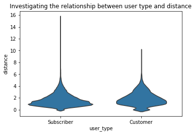

```python
base_color = sb.color_palette()[0]
sb.violinplot(data=df2, x='user_type', y='distance', color=base_color, inner=None)
plt.title('Investigating the relationship between user type and distance')
```

OBSERVATION:

As seen on the plot, more subscribers have a ride distance below 2km. Neglecting the outliers, more customers engage in long diatance rides compared to subscribers

### Talk about some of the relationships you observed in this part of the investigation. How did the feature(s) of interest vary with other features in the dataset?

As seen in the visualizations above, the relationship between ride duration (duration_sec) and the observed features differs.

The distance variable has a positive relationship with ride duration as the ride duration increases with increasing ride diatance.

With respect to the member's gender, more males uses bikeshare, followed by female, then others. The ride duration for the three categories is slightly similar, though, other then to spend a few more seconds on the trip compared to the two other groups

For the bike_share_for all trips, those who do not use bike share for all the trip spend more time on the trip compare to those who used bikeshare.

### Did you observe any interesting relationships between the other features (not the main feature(s) of interest)?

The relationship between user type and ride distance was looked into. And as seen on the plot, more subscribers have a ride distance below 2km. Negleting the outliers, more customers engage in long distance rides compared to subscribers

## 1. member_birth_year vs member_gender vs durarion sec

QUESTION: What's the relationship between member birth year, member gender and ride duration?

Now, let us look at the relationship between member birth year, ride duration and member gender

VISUALIZATION:

```
Text(0,0.5,'Duration_sec(seconds)')
```

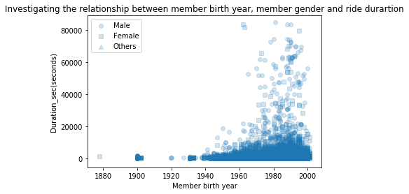

```python
gender_markers = [['Male', 'o'],
               ['Female', 's'],
                 ['Others', '^']]

for gender, marker in gender_markers:
    base_color= sb.color_palette()[0]
    plot_data = df1[df1['member_gender'] == gender]
    sb.regplot(data = plot_data, x = 'member_birth_year', y = 'duration_sec', color= base_color, x_jitter = 0.04, fit_reg =False, scatter_kws= {'alpha':1/5}, marker = marker)
plt.legend(['Male','Female', 'Others'])
plt.xlabel('Member birth year')
plt.title('Investigating the relationship between member birth year, member gender and ride durartion')
plt.ylabel('Duration_sec(seconds)')
```

## 2. member_birth_year vs bike_share_for_all_trip vs durarion sec

QUESTION: What's the relationship betweenmember birth year, bike_share_for_all_trip and ride duration?

Let us now examine the relationship between member birth year, bikeshare for all trip and ride duration

VISUALIZATION:

```
Text(0,0.5,'Duration_sec(seconds)')
```

[figure not shown]

```python
trip_markers = [['Yes', 'o'],
               ['No', '^']]

for trip, marker in trip_markers:
    base_color= sb.color_palette()[0]
    plot_data = df1[df1['bike_share_for_all_trip'] == trip]
    sb.regplot(data = plot_data, x = 'member_birth_year', y = 'duration_sec',x_jitter = 0.1, color=base_color , scatter_kws= {'alpha':1/2}, fit_reg =False,  marker = marker)
plt.legend(['Yes','No'])
plt.xlabel('Member birth year')
plt.title('Investigating the relationship between member birth year, member gender and ride durartion')
plt.ylabel('Duration_sec(seconds)')
```

### Talk about some of the relationships you observed in this part of the investigation. Were there features that strengthened each other in terms of looking at your feature(s) of interest?

I extended my investigation of ride duration against member birth year in this section by looking at the impact of the two categorical quality features: member's gender and bikeshare for all trips.

b. The relationship between ride duration and member birth year was influenced by whether or not an individual uses bikeshare for the whole trip. It was observed that for members born between 1940 and 2000, those who didn't use bikeshare for the whole trip have higher trip duration than those who used bikeshare.

### Were there any interesting or surprising interactions between features?

The result from (b) above implies that all things being equal, using bikeshare for once trip helps to save more time